# BCNI Code Examples

### Effect of normalization on the election data

```r
d$afd_vote <- scale( d$afd_vote )
d$christian <- scale( d$christian )
# regression using lavaan package
mdl <- sem( "
afd_vote ~ east + christian
christian ~ east
", d )
summary( mdl )
```

```
lavaan 0.6-18 ended normally after 1 iteration

  Estimator                                         ML
  Optimization method                           NLMINB
  Number of model parameters                         5

  Number of observations                           273

Model Test User Model:

  Test statistic                                 0.000
  Degrees of freedom                                 0

Parameter Estimates:

  Standard errors                             Standard
  Information                                 Expected
  Information saturated (h1) model          Structured

Regressions:
                   Estimate  Std.Err  z-value  P(>|z|)
  afd_vote ~
    east              2.897    0.168   17.242    0.000
    christian         0.322    0.064    5.063    0.000
  christian ~
    east             -2.258    0.083  -27.141    0.000

Variances:
                   Estimate  Std.Err  z-value  P(>|z|)
   .afd_vote          0.297    0.025   11.683    0.000
   .christian         0.269    0.023   11.683    0.000
```

What do these coefficients means?

=> Since the variables are standardized, each coefficient represents the effect in terms of standard deviations

East → Christian: -2.258

- like before it indicates a negative relationship
- Since the coefficient is standardized, this concerns a one-unit increase in the variable “East”. So east=0 (Wessi) changed to east=1 (Ossi)
- Increasing one-unit in east, corresponds with a 2.258 standard deviation decrease in the “Christian” variable.
- this has the same interpretation as before. Being east German makes it much less likely to be christian.

East → AfD Vote: 2.897

- similar interpretation as with christian but now positive

Christian → AfD Vote: 0.322

- As the data is standardized it is now even clearer (because better comparable) that the effect of being christian is much smaller than being east German

### The do-operator with SEMs

What’s the effect of the share of christian voters on the vote share of the AFD?

```r
# naive approach with a simple regression
lm( afd_vote ~ christian, d )
```

```
Call:
lm(formula = afd_vote ~ christian, data = d)

Coefficients:
(Intercept)    christian
  1.570e-16   -6.142e-01
```

The resulting negative correlation is the same as we plotted before where the Simpsons paradox was highlighted for this dataset. To remove this confounding the do-operator is used.

```r
mdl_do <- sem( "
afd_vote ~ east + christian
", d ) # deleted christian ~ east
summary(mdl_do)
```

```
lavaan 0.6-18 ended normally after 1 iteration

  Estimator                                         ML
  Optimization method                           NLMINB
  Number of model parameters                         3

  Number of observations                           273

Model Test User Model:

  Test statistic                                 0.000
  Degrees of freedom                                 0

Parameter Estimates:

  Standard errors                             Standard
  Information                                 Expected
  Information saturated (h1) model          Structured

Regressions:
                   Estimate  Std.Err  z-value  P(>|z|)
  afd_vote ~
    east              2.897    0.168   17.242    0.000
    christian         0.322    0.064    5.063    0.000

Variances:
                   Estimate  Std.Err  z-value  P(>|z|)
   .afd_vote          0.297    0.025   11.683    0.000
```

More complicated inference with multiple treks can be done via dagitty

```r
library( dagitty )
g <- lavaanToGraph( mdl, digits=4 ) # Convert lavaan model to dagitty
# digits defines parameter precision, only use this for plotting!
g
```

```
dag {
afd_vote
christian
east
christian -> afd_vote [beta="0.3218"]
east -> afd_vote [beta="2.897"]
east -> christian [beta="-2.258"]
}
```

```r
impliedCovarianceMatrix( g ) # assumes all residual variances are set to values that generate a variance of 1 for all observed variables
```

```
           afd_vote christian      east
afd_vote   1.000000 -6.219626  2.170376
christian -6.219626  1.000000 -2.258000
east       2.170376 -2.258000  1.000000
```

Do-operations with dagitty

```r
g_do <- 'dag {
 afd_vote
 christian
 east
 christian -> afd_vote [beta="0.3218"]
 east -> afd_vote [beta="2.897"]
}'
impliedCovarianceMatrix( g_do )['christian','afd_vote']
```

```
[1] 0.3218
```

Same result as we got before from the manual do-operator.

Now do-operation for east -> afd_vote

```r
impliedCovarianceMatrix( g )['east','afd_vote'] # dagitty do-operation
```

```
[1] 2.170376
```

```r
lm( afd_vote ~ east, d ) # simple regression as before
```

```
Call:
lm(formula = afd_vote ~ east, data = d)

Coefficients:
(Intercept)         east
    -0.3737       2.1705
```

As the interventional graph will be the same as the original graph the do-operator finds the same result as the naive regression. As east has no parents you don’t intervene on any incoming arrows.

## Chapter 4 - Latent Variables

This chapter concerns latent variables in linear-Gaussian Bayesian networks, also known as structural equation models (SEMs)

### Building a simple path model

```r
hsb2 <- read.table('https://stats.idre.ucla.edu/wp-content/uploads/2016/02/hsb2-2.csv', header=T, sep=",")
head(hsb2)
```

|  | id | female | race | ses | schtyp | prog | read | write | math | science | socst |
| --- | --- | --- | --- | --- | --- | --- | --- | --- | --- | --- | --- |
| 1 | 70 | 0 | 4 | 1 | 1 | 1 | 57 | 52 | 41 | 47 | 57 |
| 2 | 121 | 1 | 4 | 2 | 1 | 3 | 68 | 59 | 53 | 63 | 61 |
| 3 | 86 | 0 | 4 | 3 | 1 | 1 | 44 | 33 | 54 | 58 | 31 |
| 4 | 141 | 0 | 4 | 3 | 1 | 3 | 63 | 44 | 47 | 53 | 56 |
| 5 | 172 | 0 | 4 | 2 | 1 | 2 | 47 | 52 | 57 | 53 | 61 |
| 6 | 113 | 0 | 4 | 2 | 1 | 2 | 44 | 52 | 51 | 63 | 61 |

```r
hsb2 <- as.data.frame(scale(hsb2[,c("read","write","math","science")])) # Normalizing
```

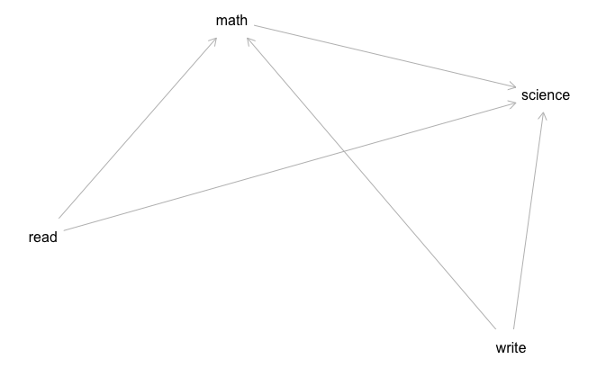

```r
dag1 <- graphLayout(dagitty("dag{{read write} -> {math->science}}"))
plot(dag1)
```

```r
cor.test( hsb2[['read']], hsb2[['write']] )
```

```
    Pearson's product-moment correlation

data:  hsb2[["read"]] and hsb2[["write"]]
t = 10.465, df = 198, p-value < 2.2e-16
alternative hypothesis: true correlation is not equal to 0
95 percent confidence interval:
 0.4993831 0.6792753
sample estimates:
      cor
0.5967765
```

The graph suggests that there should be no correlation between read and write but the data shows there is.

### Fitting implicit latent variables

We add an implicit variable between read and write to counter the found correlation.

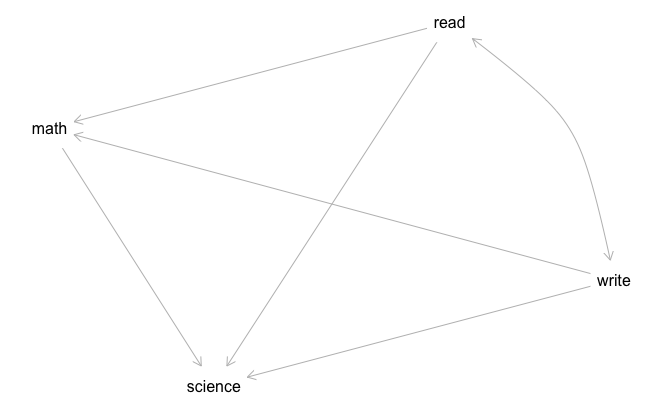

```r
dag2 <- graphLayout(dagitty("dag{{read <-> write} -> {math->science}}"))
plot(dag2)
```

Then we use lavaan to fit the updated model

```r
lvsem <- toString(dag2,"lavaan")
lvsem.fit <- sem(lvsem,hsb2)
summary(lvsem.fit)
```

```
lavaan 0.6-18 ended normally after 13 iterations

  Estimator                                         ML
  Optimization method                           NLMINB
  Number of model parameters                        10

  Number of observations                           200

Model Test User Model:

  Test statistic                                 0.000
  Degrees of freedom                                 0

Parameter Estimates:

  Standard errors                             Standard
  Information                                 Expected
  Information saturated (h1) model          Structured

Regressions:
                   Estimate  Std.Err  z-value  P(>|z|)
  science ~
    math              0.302    0.072    4.203    0.000
  math ~
    read              0.456    0.061    7.438    0.000
  science ~
    read              0.312    0.070    4.435    0.000
  math ~
    write             0.345    0.061    5.626    0.000
  science ~
    write             0.198    0.067    2.948    0.003

Covariances:
                   Estimate  Std.Err  z-value  P(>|z|)
  read ~~
    write             0.594    0.082    7.247    0.000

Variances:
                   Estimate  Std.Err  z-value  P(>|z|)
   .science           0.498    0.050   10.000    0.000
   .math              0.482    0.048   10.000    0.000
    read              0.995    0.100   10.000    0.000
    write             0.995    0.100   10.000    0.000
```

The correlation between read <-> write is the same as the basic correlation calculated earlier!

### Estimating the values of latent variables

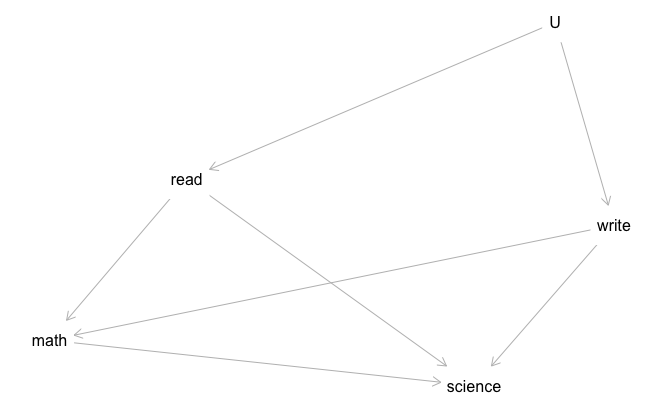

```r
dag3 <- graphLayout(dagitty("dag{U [latent] U -> {read write} -> {math->science}}"))
plot(dag3)
```

Fit this model via lavaan

```r
lvsem3 <- toString(dag3,"lavaan")
lvsem3.fit <- sem(lvsem3,hsb2)
```

The model is not identified (several combinations can explain the same covariance) and can therefore not be fitted. We resolve this in the same way as in the lecture. We put the constraint that we imply that both coefficients coming from U are equal. That way we have one parameter to fit.

```r
cat(lvsem3)
```

```
# Please set lavaan's fixed.x appopriately!
U=~read
U=~write
science~math
math~read
science~read
math~write
science~write
```

```r
# =~ indicates a latent variable
# U and read and write have different coefficients here
```

Now we make the coefficients outgoing from U equal. Here we call the coefficient “l”

```r
lvsem3 <- "
U =~ l*read
U =~ l*write
science~math
math~read
science~read
math~write
science~write
"
```

Now the model is identified and can be fitted

```r
lvsem3.fit <- sem(lvsem3,hsb2)
```

```r
head(hsb2)
```

|  | read | write | math | science |
| --- | --- | --- | --- | --- |
| 1 | 0.4652326 | -0.08176325 | -1.24300207 | -0.4898549 |
| 2 | 1.5380959 | 0.65674353 | 0.03789315 | 1.1261613 |
| 3 | -0.8026968 | -2.08628164 | 0.14463442 | 0.6211562 |
| 4 | 1.0504307 | -0.92577099 | -0.60255446 | 0.1161512 |
| 5 | -0.5100977 | -0.08176325 | 0.46485822 | 0.1161512 |
| 6 | -0.8026968 | -0.08176325 | -0.17558939 | 1.1261613 |

```r
hsb2$U <- as.numeric(predict(lvsem3.fit))
head(hsb2)
```

|  | read | write | math | science | U |
| --- | --- | --- | --- | --- | --- |
| 1 | 0.4652326 | -0.08176325 | -1.24300207 | -0.4898549 | 0.14331716 |
| 2 | 1.5380959 | 0.65674353 | 0.03789315 | 1.1261613 | 0.82029549 |
| 3 | -0.8026968 | -2.08628164 | 0.14463442 | 0.6211562 | -1.07972182 |
| 4 | 1.0504307 | -0.92577099 | -0.60255446 | 0.1161512 | 0.04659012 |
| 5 | -0.5100977 | -0.08176325 | 0.46485822 | 0.1161512 | -0.22120111 |
| 6 | -0.8026968 | -0.08176325 | -0.17558939 | 1.1261613 | -0.33055659 |

```r
CorM <- lavCor(hsb2)
```

```
Error: lavaan->lav_samplestats_icov():
   sample covariance matrix is not positive-definite
```

```r
plotLocalTestResults(results)
```

[output not shown]

### Example application

```r
library( bnlearn )
net3 <- model2network(toString(dag3,"bnlearn"))
fit3 <- bn.fit( net3, hsb2 )
fit3
```

```
  Bayesian network parameters

  Parameters of node math (Gaussian distribution)

Conditional density: math | read + write
Coefficients:
  (Intercept)           read          write
-5.294170e-16   4.563134e-01   3.451322e-01
Standard deviation of the residuals: 0.6997227

  Parameters of node read (Gaussian distribution)

Conditional density: read | U
Coefficients:
 (Intercept)             U
5.568066e-16  1.337835e+00
Standard deviation of the residuals: 0.4501444

  Parameters of node science (Gaussian distribution)

Conditional density: science | math + read + write
Coefficients:
  (Intercept)           math           read          write
-2.027376e-16   3.018540e-01   3.122533e-01   1.977167e-01
Standard deviation of the residuals: 0.7125376

  Parameters of node U (Gaussian distribution)

Conditional density: U
Coefficients:
  (Intercept)
-1.838894e-16
Standard deviation of the residuals: 0.6678895

  Parameters of node write (Gaussian distribution)

Conditional density: write | U
Coefficients:
 (Intercept)             U
3.942630e-16  1.337835e+00
Standard deviation of the residuals: 0.4501444
```

```r
rbn( fit3, n=5 )
```

| math | read | science | U | write |
| --- | --- | --- | --- | --- |
| 1.8380535 | 1.3204324 | 0.09850024 | 1.02750142 | 1.6176107053 |
| 1.1185015 | 0.3578927 | 0.17360275 | -0.07327437 | 0.1794651074 |
| 0.2632686 | 0.3663270 | 0.66504860 | 0.34160596 | 0.7345568467 |
| -0.7534554 | -0.7260744 | -1.71967734 | 0.14290029 | -0.5705131019 |
| 0.9248411 | -0.2544821 | 0.39888689 | -0.12430807 | -0.0003164538 |

## Chapter 5 - Polychoric Correlations for Ordinal Data

### Building a DAG with both continuous and discrete variables

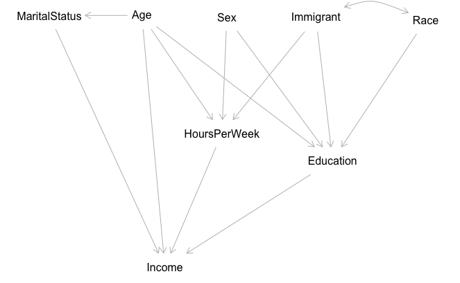

```r
d <- read.csv('adult.csv')
g <- dagitty('dag {
bb="-4.642,-3.798,3.662,3.731"
Age [pos="-2.030,-2.640"]
Education [pos="1.359,0.455"]
HoursPerWeek [pos="-0.607,-0.125"]
Immigrant [pos="1.065,-2.590"]
Income [pos="-1.620,2.722"]
MaritalStatus [pos="-3.674,-2.640"]
Race [pos="3.016,-2.540"]
Sex [pos="-0.519,-2.607"]
Age -> { Education HoursPerWeek Income MaritalStatus } Education -> Income
HoursPerWeek -> Income
Immigrant -> { Education HoursPerWeek }
Immigrant <-> Race
MaritalStatus -> Income
Race -> Education
Sex -> { Education HoursPerWeek }
}')
plot(g)
```

### Preprocessing for polychoric correlations

For these variables the assumption that their nature is actually continuous seems valid.

```r
d$Age <- ordered( d$Age, levels=c("<20","20-34","35-49","50-65",">65") )
d$Education <- ordered( d$Education, levels=c("Non-HS-Grad","HS-grad",
"College-Associate","Academic-Degree"))
d$Income <- ordered( d$Income, c("<=50K",">50K") )
d$HoursPerWeek <- ordered( d$HoursPerWeek, c("<20","20-39","40",">40") )
```

These variables are not continuous in nature, so polychoric correlations cannot be used here. But they are only binary and therefore can still be used (via one-hot encoding I think)

```r
d$Race <- as.numeric( ordered( d$Race, c("White","Non-White") ) )
d$Sex <- as.numeric( ordered( d$Sex, c("Male","Female") ) )
d$Immigrant <- as.numeric( ordered( d$Immigrant, c("no","yes") ) )
```

Problematic is MaritalStatus because it has three instances and not continuous but categorical in nature

```r
table(d$MaritalStatus)
```

```
   Is-Married Never-married   Was-Married
        14456          9726          5980
```

We simply make it binary by only distinguishing married or not married.

```r
d$MaritalStatus <- as.integer( d$MaritalStatus == "Is-Married" )
```

Now all data is fit as if we were dealing with only continuous variables. Therefore we can use standard SEM

```r
# Extract polychoric correlation matrix
M <- lavCor(d)
M
```

```
                 Age Eductn MrtlSt   Race    Sex HrsPrW Immgrn Income
Age            1.000
Education      0.084  1.000
MaritalStatus  0.317  0.075  1.000
Race          -0.024 -0.054 -0.097  1.000
Sex           -0.087 -0.001 -0.426  0.105  1.000
HoursPerWeek   0.140  0.197  0.260 -0.088 -0.279  1.000
Immigrant     -0.014 -0.089  0.030  0.192 -0.003 -0.028  1.000
Income         0.352  0.465  0.560 -0.127 -0.320  0.396 -0.058  1.000
```

```r
fit <- sem( toString(g,"lavaan"), sample.cov=M, sample.nobs=nrow(d) )
summary(fit)
```

```
lavaan 0.6-18 ended normally after 11 iterations

  Estimator                                         ML
  Optimization method                           NLMINB
  Number of model parameters                        19

  Number of observations                         30162

Model Test User Model:

  Test statistic                              8816.397
  Degrees of freedom                                14
  P-value (Chi-square)                           0.000

Parameter Estimates:

  Standard errors                             Standard
  Information                                 Expected
  Information saturated (h1) model          Structured

Regressions:
                   Estimate  Std.Err  z-value  P(>|z|)
  Education ~
    Age               0.083    0.006   14.509    0.000
  HoursPerWeek ~
    Age               0.117    0.006   21.168    0.000
  Income ~
    Age               0.156    0.004   37.730    0.000
  MaritalStatus ~
    Age               0.317    0.005   58.122    0.000
  Income ~
    Education         0.383    0.004   98.679    0.000
    HoursPerWeek      0.186    0.004   47.541    0.000
  Education ~
    Immigrant        -0.080    0.006  -13.749    0.000
  HoursPerWeek ~
    Immigrant        -0.027    0.005   -4.969    0.000
  Income ~
    MaritalStatus     0.434    0.004  106.362    0.000
  Education ~
    Race             -0.038    0.006   -6.553    0.000
    Sex               0.010    0.006    1.718    0.086
  HoursPerWeek ~
    Sex              -0.269    0.006  -48.845    0.000

Covariances:
                   Estimate  Std.Err  z-value  P(>|z|)
  Immigrant ~~
    Race              0.192    0.006   32.766    0.000

Variances:
                   Estimate  Std.Err  z-value  P(>|z|)
   .Education         0.984    0.008  122.805    0.000
   .HoursPerWeek      0.908    0.007  122.805    0.000
   .Income            0.451    0.004  122.805    0.000
   .MaritalStatus     0.899    0.007  122.805    0.000
    Immigrant         1.000    0.008  122.805    0.000
    Race              1.000    0.008  122.805    0.000
```

Plotting

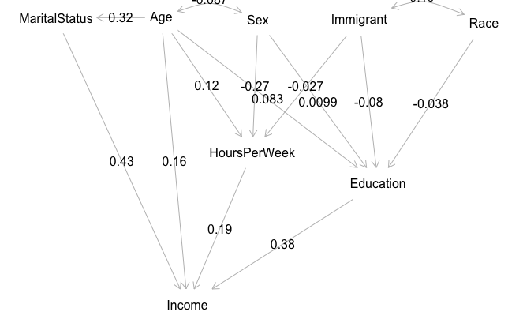

```r
cg <- coordinates(g)
fg <- lavaanToGraph(fit, digits=2)
coordinates(fg) <- cg
plot(fg, show.coefficients=TRUE)
```

## Chapter 6 - Canonical Correlation Analysis

### Building a DAG with both continuous and discrete variables

```r
library(fastDummies) # used by dagitty for dummy coding
library(CCP) # used by dagitty to compute p-values for canonical correlation coefficients

d <- read.csv("adult.data",header=FALSE,
              na.strings="?",sep=",",strip.white=TRUE,stringsAsFactors=TRUE)
colnames(d) <- c("Age","Workclass","Fnlwgt","Education","EducationNum", "MaritalStatus","Occupation","Relationship","Race","Sex","CapitalGain", "CapitalLoss","HoursPerWeek","NativeCountry","Income")
# “Fnlwgt”, “CapitalGain”,“CapitalLoss”,“Relationship”, and “MaritalStatus” are omitted for this example
```

Preprocessing

```r
# Tell R about which variables are ordinal
d$Education <- as.integer(d$EducationNum) # ordinal variable “Education” by coding it as an integer, which may not be ideal
d$Income <- ordered(d$Income)

d <- d[,-which(colnames(d)=="EducationNum")]

d$NativeCountry <- as.character( d$NativeCountry )
d$NativeCountry[!d$NativeCountry %in% c("United-States","Mexico")] <- "Other"
d$NativeCountry <- factor( d$NativeCountry )

# Drop rows containing missing data
d <- d[complete.cases(d),]
```

DAG for this dataset

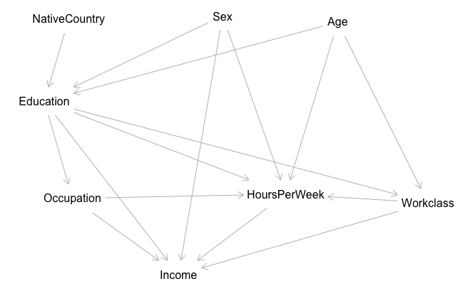

```r
g <- dagitty('
dag {
bb="0,0,1,1"
Age [pos="0.7,0.203"]
Education [pos="0.147,0.368"]
HoursPerWeek [pos="0.602,0.562"]
Income [pos="0.4,0.730"]
NativeCountry [pos="0.193,0.197"]
Occupation [pos="0.2,0.571"]
Sex [pos="0.483,0.190"]
Workclass [pos="0.870,0.580"]
Age -> { Education HoursPerWeek Workclass }
Education -> { HoursPerWeek Income Occupation Workclass } HoursPerWeek -> Income
NativeCountry -> Education
Occupation -> { HoursPerWeek Income }
Sex -> { Education HoursPerWeek Income }
Workclass -> { HoursPerWeek Income }
}
')
plot(g)
```

Lavaan cannot be used for this data as it only allows categorial values for nodes without parents (see east Germany example). Instead they use this code for computing canonical correlations:

```r
r <- c()
for( n in names(g) ){
  for( p in dagitty::parents(g,n) ){
    otherparents <- setdiff( dagitty::parents(g,n), p )
    tst <- ciTest( X=n, Y=p, Z=otherparents, d,
      type="cis.pillai" )
    r <- rbind( r, data.frame(list(X=p,A="->",Y=n,
      cor=tst[,"estimate"],p=tst[,"p.value"])) )
  }
}
r
```

| X | A | Y | cor | p |
| --- | --- | --- | --- | --- |
| Age | -> | Education | 0.03077802 | 6.837735e-08 |
| NativeCountry | -> | Education | 0.21975019 | 0.000000e+00 |
| Sex | -> | Education | 0.01273521 | 2.561214e-02 |
| Age | -> | HoursPerWeek | 0.04067630 | 9.905466e-13 |
| Education | -> | HoursPerWeek | 0.11032375 | 8.607280e-84 |
| Occupation | -> | HoursPerWeek | 0.18727133 | 0.000000e+00 |
| Sex | -> | HoursPerWeek | 0.15115961 | 2.033038e-156 |
| Workclass | -> | HoursPerWeek | 0.10188983 | 0.000000e+00 |
| Education | -> | Income | 0.18553189 | 5.664775e-236 |
| HoursPerWeek | -> | Income | 0.12144853 | 2.890183e-101 |

[output cut: 6 more lines]

Plotting

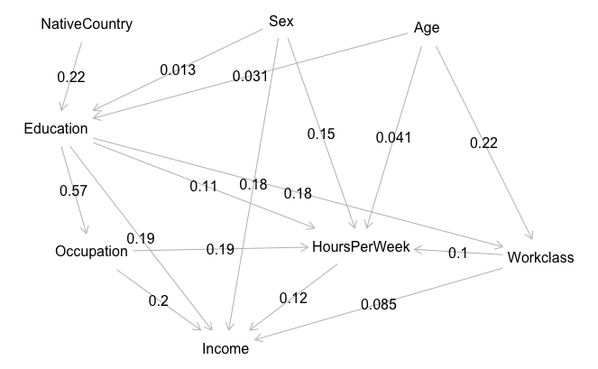

```r
# converting to dagitty formatted string
r.dagitty <- paste(r$X, r$A, r$Y, "[beta=",signif(r$cor,2),"] ", collapse="\n")
g_with_coefficients <- dagitty( r.dagitty )
coordinates( g_with_coefficients ) <- coordinates( g )
plot( g_with_coefficients, show.coefficients=TRUE )
```

The plot shows that for example the edge between Sex and Education can probably be omitted.

## Chapter 7 - Testing Causal Diagrams

```r
library( dagitty )
library( bayesianNetworks )
```

### Discovering causal diagram misspecifications

Showing implied Conditional Independencies

```r
g <- graphLayout(dagitty("dag{FI->{LE MD}->D MG->{MD D}}"))
impliedConditionalIndependencies(g)
```

```
D _||_ FI | LE, MD, MG
FI _||_ MG
LE _||_ MD | FI
LE _||_ MG
```

###Data loading and non-conditional independence tests

#### Small Recap on Chi-Square test:

- is for categorical data
- generates a null distribution in which the variables of interest are independent
- the real data is then compared to the null distribution with the X^2 formular (X^2 is also called residuals in the slides)
- the sum of these residuals is chi-squared, which looks like X^2
- then you apply a statistical test and get the p-value = 1 - pchisq(chi-square, degrees_of_freedom)
- for several categories you combine p-values to avoid multiple testing

for LE *||* MG

```r
d <- read.csv("diabetes.csv")
chisq.test( d$LE, d$MG ) # Graph indicates full independence. The p-value supports this.
```

```
    Pearson's Chi-squared test with Yates' continuity correction

data:  d$LE and d$MG
X-squared = 0.19875, df = 1, p-value = 0.6557
```

```r
# The p-value expresses that the probability of LE being independent of MG with the given data is 65.6% and therefore very likely.
```

for FI *||* MG

```r
chisq.test( d$FI, d$MG ) # this independence seems unlikely, given the low p-value
```

```
    Pearson's Chi-squared test with Yates' continuity correction

data:  d$FI and d$MG
X-squared = 23.518, df = 1, p-value = 1.238e-06
```

### Conditional independence tests

for LE *||* MD | FI

```r
chisq <- 0 ; df <- 0
for( x in unique(d$FI) ){ # per FI value
  tst <- chisq.test( d$LE[d$FI==x], d$MD[d$FI==x] ) # you get a test statistic between LE and MD per FI value
  chisq <- chisq + tst$statistic # combine these test statistics into a single value
  df <- df + tst$parameter # and count total degrees of freedom
}
chisq # final test statistic
```

```
 X-squared
0.03375659
```

```r
df # total degrees of freedom
```

```
df
 2
```

```r
1-pchisq(chisq,df) # why the heck is this called X^2? I think this should be a p-value
```

```
X-squared
0.9832633
```

Not sure if this is actually a low X^2 or high p-value. Either way it would indicate that LE *||* MD | FI seems valid. Looking at the results of the automated test this indeed seems like the p-value.

### Automated test for Conditional Independencies

```r
localTests(g, d, type="cis.chisq")
```

|  | rmsea | x2 | df | p.value | rmsea 2.5% | rmsea 97.5% |
| --- | --- | --- | --- | --- | --- | --- |
| D _\|\|_ FI \| LE, MD, MG | 0.07078632 | 10.7939197 | 8 | 2.136516e-01 | 0.0000000 | 0.3710545 |
| FI _\|\|_ MG | 0.21652703 | 24.3950932 | 1 | 7.846830e-07 | 0.1256285 | 0.3055847 |
| LE _\|\|_ MD \| FI | 0.00000000 | 0.1173820 | 2 | 9.429981e-01 | 0.0000000 | 0.1317835 |
| LE _\|\|_ MG | 0.00000000 | 0.2865027 | 1 | 5.924704e-01 | 0.0000000 | 0.1033122 |

Family income and MaternalGenetics fail the test according to this table. The data suggests that they are dependent.

### Model testing using polychoric correlations

Loading and preprocessing in Chapter 5 - Polychoric Correlations …

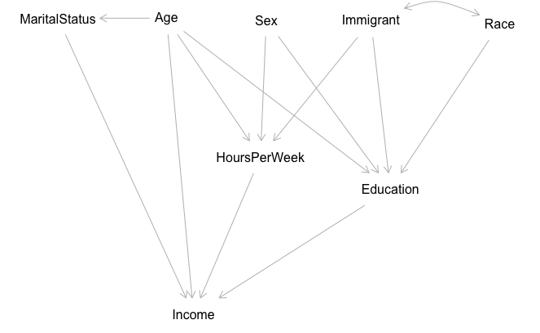

```r
d <- read.csv('adult.csv')
d$Age <- ordered( d$Age, levels=c("<20","20-34","35-49","50-65",">65") )
d$Education <- ordered( d$Education, levels=c("Non-HS-Grad","HS-grad",
"College-Associate","Academic-Degree"))
d$Income <- ordered( d$Income, c("<=50K",">50K") )
d$HoursPerWeek <- ordered( d$HoursPerWeek, c("<20","20-39","40",">40") )
d$Race <- as.numeric( ordered( d$Race, c("White","Non-White") ) )
d$Sex <- as.numeric( ordered( d$Sex, c("Male","Female") ) )
d$Immigrant <- as.numeric( ordered( d$Immigrant, c("no","yes") ) )
d$MaritalStatus <- as.integer( d$MaritalStatus == "Is-Married" )

g <- dagitty('dag {
bb="-4.642,-3.798,3.662,3.731"
Age [pos="-2.030,-2.640"]
Education [pos="1.359,0.455"]
HoursPerWeek [pos="-0.607,-0.125"]
Immigrant [pos="1.065,-2.590"]
Income [pos="-1.620,2.722"]
MaritalStatus [pos="-3.674,-2.640"]
Race [pos="3.016,-2.540"]
Sex [pos="-0.519,-2.607"]
Age -> { Education HoursPerWeek Income MaritalStatus } Education -> Income
HoursPerWeek -> Income
Immigrant -> { Education HoursPerWeek }
Immigrant <-> Race
MaritalStatus -> Income
Race -> Education
Sex -> { Education HoursPerWeek }
}')

plot(g)
```

Automated chi-square testing

```r
localTests(g,d, type='cis.chisq')
```

|  | rmsea | x2 | df | p.value | rmsea 2.5% | rmsea 97.5% |
| --- | --- | --- | --- | --- | --- | --- |
| Age _\|\|_ Immg | 0.02110776 | 57.7514122 | 4 | 8.605148e-12 | 0.015871775 | 0.02742578 |
| Age _\|\|_ Race | 0.02081284 | 56.2598622 | 4 | 1.768747e-11 | 0.015579209 | 0.02714107 |
| Age _\|\|_ Sex | 0.04865666 | 289.6210863 | 4 | 1.876589e-61 | 0.043240642 | 0.05457584 |
| Edct _\|\|_ HrPW \| Age, Immg, Sex | 0.06533604 | 1359.6585666 | 171 | 4.621332e-184 | 0.040660533 | 0.15312555 |
| Edct _\|\|_ MrtS \| Age | 0.04916625 | 196.0220416 | 15 | 1.364523e-33 | 0.027435608 | 0.07383515 |
| HrPW _\|\|_ MrtS \| Age | 0.09780792 | 1127.7680566 | 15 | 5.295478e-231 | 0.077017632 | 0.12133414 |
| HrPW _\|\|_ Race \| Immg | 0.04431913 | 410.0218517 | 6 | 1.957253e-85 | 0.031530228 | 0.06268533 |
| Immg _\|\|_ Incm \| Age, Edct, HrPW | 0.03001939 | 66.1162565 | 61 | 3.047291e-01 | 0.000000000 | 0.22085968 |
| Immg _\|\|_ MrtS | 0.02990421 | 27.9718211 | 1 | 1.230950e-07 | 0.018282593 | 0.04134005 |
| Immg _\|\|_ Sex | 0.00000000 | 0.2724872 | 1 | 6.016682e-01 | 0.000000000 | 0.01321632 |

[output cut: 6 more lines]

Attention: This is not the best result due to the binned categories.

- for example look at Edct *||* HrPW | Age, Immg, Sex where 171 DoF were needed. This stems from the fact that age is binned in many categories instead of it being a continuous variable.
- The chi-square test requires as a rule of thumb at least 5 samples per category (due to central limit theorem). Therefore the results of this test are probably unreliable.
- to resolve this we need to use polychoric correlations to estimate a continuous correlation of the binned data

Testing with polychoric relations -> linear regression coefficients

```r
M <- lavCor(d) # Polychoric correlation matrix
# Test model using polychoric correlation matrix
results <- localTests( g, sample.cov=M, sample.nobs=nrow(d) )
results
```

|  | estimate | p.value | 2.5% | 97.5% |
| --- | --- | --- | --- | --- |
| Age _\|\|_ Immg | -0.013766498 | 1.680764e-02 | -0.02504812 | -0.002481374 |
| Age _\|\|_ Race | -0.023568238 | 4.245434e-05 | -0.03484448 | -0.012285996 |
| Age _\|\|_ Sex | -0.086984738 | 8.257393e-52 | -0.09817448 | -0.075773780 |
| Edct _\|\|_ HrPW \| Age, Immg, Sex | 0.195438303 | 4.833065e-259 | 0.18457376 | 0.206294661 |
| Edct _\|\|_ MrtS \| Age | 0.050711171 | 1.206584e-18 | 0.03944806 | 0.061961468 |
| HrPW _\|\|_ MrtS \| Age | 0.229278589 | 0.000000e+00 | 0.21859223 | 0.239997517 |
| HrPW _\|\|_ Race \| Immg | -0.084380882 | 7.631673e-49 | -0.09557610 | -0.073164999 |
| Immg _\|\|_ Incm \| Age, Edct, HrPW | -0.015910400 | 5.724627e-03 | -0.02719159 | -0.004625160 |
| Immg _\|\|_ MrtS | 0.030453015 | 1.221746e-07 | 0.01917410 | 0.041724194 |
| Immg _\|\|_ Sex | -0.003005682 | 6.016852e-01 | -0.01429071 | 0.008280109 |

[output cut: 6 more lines]

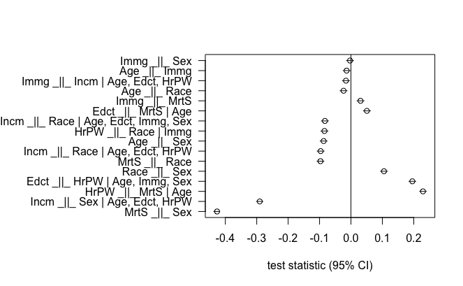

```r
plotLocalTestResults( results )
```

### Model testing using canonical correlations

Again, refer back to Chapter 6, preprocessign was done in the same way there.

```r
d <- read.csv("adult.data",header=FALSE, na.strings="?",sep=",",strip.white=TRUE,stringsAsFactors=TRUE)
colnames(d) <- c("Age","Workclass","Fnlwgt","Education","EducationNum", "MaritalStatus","Occupation","Relationship","Race","Sex","CapitalGain", "CapitalLoss","HoursPerWeek","NativeCountry","Income")
d$Education <- as.integer(d$EducationNum)
d$Income <- ordered(d$Income)
d <- d[,-which(colnames(d)=="EducationNum")]
d$NativeCountry <- as.character( d$NativeCountry )
d$NativeCountry[!d$NativeCountry %in% c("United-States","Mexico")] <- "Other"
d$NativeCountry <- factor( d$NativeCountry )

# Drop rows containing missing data
d <- d[complete.cases(d),]
```

Defining DAG

```r
g <- dagitty('
dag {
bb="0,0,1,1"
Age [pos="0.7,0.203"]
Education [pos="0.147,0.368"] HoursPerWeek [pos="0.602,0.562"] Income [pos="0.4,0.730"] NativeCountry [pos="0.193,0.197"] Occupation [pos="0.2,0.571"]
Sex [pos="0.483,0.190"]
Workclass [pos="0.870,0.580"]
Age -> { Education HoursPerWeek Workclass }
Education -> { HoursPerWeek Income Occupation Workclass }
HoursPerWeek -> Income
NativeCountry -> Education
Occupation -> { HoursPerWeek  Income }
Sex -> { Education HoursPerWeek Income }
Workclass -> { HoursPerWeek Income }
}
')
```

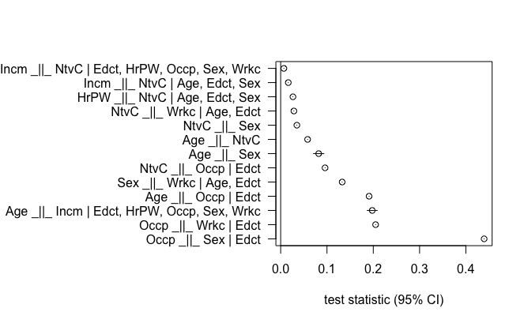

```r
r <- localTests(g,d, type='cis.pillai')
plotLocalTestResults( r )
```

Confidence intervals are not implemented yet for the categorical data. Only when they are binary. Thats why most of the variables do not show the bounds.

#### Analyzing the relationship Occp *||* Sex | Education

The drop=FALSE is required because if we just use d[,c(“Sex”)], R would “conveniently” convert the result (a single-column dataframe) to a vector. However, the function dummy_cols wants a dataframe as input.

```r
# One hot encoding sex
s_dummy <- dummy_cols( d[,c("Sex"),drop=FALSE], remove_most_frequent_dummy=TRUE )
head(s_dummy)
```

|  | Sex | Sex_Female |
| --- | --- | --- |
| 1 | Male | 0 |
| 2 | Male | 0 |
| 3 | Male | 0 |
| 4 | Male | 0 |
| 5 | Female | 1 |
| 6 | Female | 1 |

```r
s_dummy <- s_dummy[,-1,drop=FALSE]
head(s_dummy)
```

|  | Sex_Female |
| --- | --- |
| 1 | 0 |
| 2 | 0 |
| 3 | 0 |
| 4 | 0 |
| 5 | 1 |
| 6 | 1 |

Transform Occupation

```r
o_dummy <- dummy_cols( d[,c("Occupation"),drop=FALSE], remove_most_frequent_dummy=TRUE )[,-1]
head(o_dummy,3)
```

|  | Occupation_Adm-clerical | Occupation_Armed-Forces | Occupation_Craft-repair | Occupation_Exec-managerial | Occupation_Farming-fishing | Occupation_Handlers-cleaners | Occupation_Machine-op-inspct | Occupation_Other-service | Occupation_Priv-house-serv | Occupation_Protective-serv | Occupation_Sales | Occupation_Tech-support | Occupation_Transport-moving |
| --- | --- | --- | --- | --- | --- | --- | --- | --- | --- | --- | --- | --- | --- |
| 1 | 1 | 0 | 0 | 0 | 0 | 0 | 0 | 0 | 0 | 0 | 0 | 0 | 0 |
| 2 | 0 | 0 | 0 | 1 | 0 | 0 | 0 | 0 | 0 | 0 | 0 | 0 | 0 |
| 3 | 0 | 0 | 0 | 0 | 0 | 1 | 0 | 0 | 0 | 0 | 0 | 0 | 0 |

```r
cancor( o_dummy, s_dummy )$cor
```

```
[1] 0.4342609
```

This number measures the unconditional dependence between Sex and Occupation.

To condition on Education, we need to add this variable to both sets of dummies. Since Education is (coded as) a numerical variable, we don’t need to do dummy coding, and we can just add it to both sides of the correlation function.

```r
cancor( cbind(o_dummy,d$Education), cbind(s_dummy,d$Education) )$cor
```

```
[1] 1.0000000 0.4394276
```

The first canonical correlation is irrelevant now – this is a result of adding “Education” to both sides. But he second canonical correlation is now conditioned on “Education”. Hence, this is our final result.

Let’s compare that to what dagitty has to say:

```r
ciTest( "Occupation", "Sex", "Education", d, type="cis.pillai" )
```

|  | estimate | p.value | 2.5% | 97.5% |
| --- | --- | --- | --- | --- |
| Occp _\|\|_ Sex \| Edct | 0.4394276 | 0 | 0.4394276 | 0.4394276 |

Which is identical!

And the corresponding p-value is computed as follows:

```r
rho <- cancor( cbind(o_dummy,d$Education), cbind(s_dummy,d$Education) )$cor
p.asym( rho, nrow(d), ncol(o_dummy)+1, ncol(s_dummy)+1, "Pillai" )
```

```
 Pillai-Bartlett Trace, using F-approximation:
              stat    approx df1   df2 p.value
1 to 2:  1.1930966 3242.7004  28 61406       0
2 to 2:  0.1930966  504.8187  13 61410       0
```